# WerdenEtAl2019_Analysis

### Plot the final full model predictions

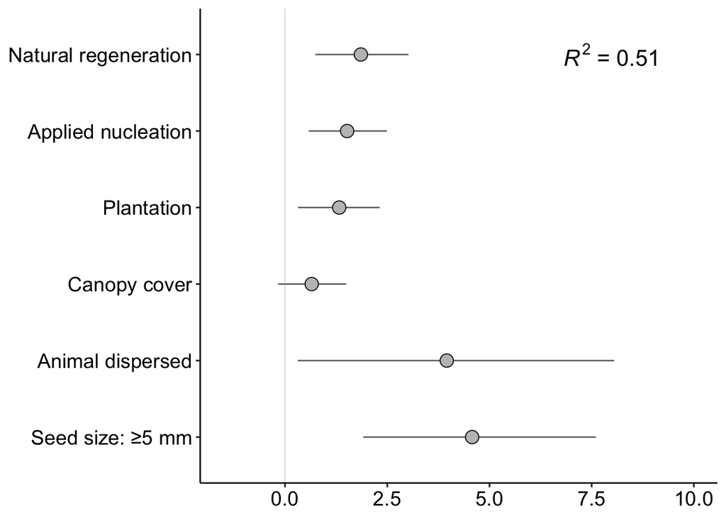

```r
# plot full model fit (Figure S2)
posteriorFigS2 <- as.array(finalModSTS_forFigS2)
dimnames(posteriorFigS2)$parameters[2] <- "Natural regeneration"
dimnames(posteriorFigS2)$parameters[3] <- "Applied nucleation"
dimnames(posteriorFigS2)$parameters[4] <- "Plantation"
dimnames(posteriorFigS2)$parameters[5] <- "Canopy cover"
dimnames(posteriorFigS2)$parameters[6] <- "Animal dispersed"
dimnames(posteriorFigS2)$parameters[7] <- "Seed size: \u22655 mm"
color_scheme_set("darkgray")
# Make Figure S2
FigureS1 <- mcmc_intervals(posteriorFigS2, prob = 0, prob_outer = 0.95,
                           pars = c("Natural regeneration", "Applied nucleation",
                                    "Plantation", "Canopy cover",
                                    "Animal dispersed", "Seed size: \u22655 mm"))+
                           theme_pubr()+
                           theme(axis.text.x = element_text(size = 14),
                           axis.text.y = element_text(size = 14))+
                           xlim(-1.5, 10)+
                           annotate("text", x = 8, y = 6, label = "paste(italic(R) ^ 2, \" = 0.51\")", parse = TRUE, size = 5.5)
FigureS1
```

```r
ggsave("FigureS1.pdf", width = 7, height = 6, units = "in", dpi = 600, device = cairo_pdf)
```

### Model STS separtately by small seeds (<5 mm) and large seeds (>=5 mm)

To determine if the influence of the predictors on the STS differed for species with small (<5 mm) or large (>=5 mm) seeds, we built the full model above including interaction terms between seed size and all predictors. The model including interaction terms did not converge due to low observations of large-seeded seedlings, so we built the full model above (excluding seed size) with our data subset by either <5 mm (finalModSTS_forFig1A) or >=5 mm seeds (finalModSTS_forFig1B).

```r
# by seed size
# small seeds (<5 mm)
finalModSTS_forFig2A <- brm(count_seedling ~ Treatment_Ref + meanCover + Dispersalmode +
                            offset(log(seedsSum_scaled)) + (1| Species) + (1|Site), # model STS as the rate of recruits/seeds with all predictors
                            data = subset(seedsAndSeedlings_forModeling_final_standard, SeedSize == "1"), # only model <5 mm seeds STS
                            family = zero_inflated_negbinomial(link = "log", link_shape = "log", link_zi = "logit"), # zero-inflated neg. binom.
                            prior = c(set_prior("normal(0, 1e6)", class = "b"), # non-informative priors for predictors
                            set_prior("normal(0, 1e6)", class = "Intercept")), # non-informative priors for intercept
                            control = list(adapt_delta = .99), # decrease divergent transitions
                            chains=4, iter=5000, warmup=2500, thin=5
                            )
```

```
## recompiling to avoid crashing R session
```

```r
# Stan code for reproducibility
#stancode(finalModSTS_forFig1A)

# visually check posterior samples - chains are well mixed and diagnostics all ok (commented out below to run knit pdf)
#launch_shinystan(finalModSTS_forFig1A)

# look at summary of sampler output: no divergent transitions and acceptance probability is high
summary(do.call(rbind, args = get_sampler_params(finalModSTS_forFig2A$fit, inc_warmup = FALSE)), digits = 2)
```

```
##  accept_stat__    stepsize__     treedepth__   n_leapfrog__  divergent__
##  Min.   :0.80   Min.   :0.023   Min.   :6.0   Min.   : 63   Min.   :0
##  1st Qu.:0.99   1st Qu.:0.024   1st Qu.:7.0   1st Qu.:127   1st Qu.:0
##  Median :0.99   Median :0.028   Median :7.0   Median :127   Median :0
##  Mean   :0.99   Mean   :0.027   Mean   :7.1   Mean   :165   Mean   :0
##  3rd Qu.:1.00   3rd Qu.:0.031   3rd Qu.:7.0   3rd Qu.:255   3rd Qu.:0
##  Max.   :1.00   Max.   :0.032   Max.   :9.0   Max.   :767   Max.   :0
##     energy__
##  Min.   :570
##  1st Qu.:587
##  Median :592
##  Mean   :592
##  3rd Qu.:598
##  Max.   :622
```

```r
# summary -- all converged @ Rhat <=1.00
summary(finalModSTS_forFig2A)
```

```
##  Family: zero_inflated_negbinomial
##   Links: mu = log; shape = identity; zi = identity
## Formula: count_seedling ~ Treatment_Ref + meanCover + Dispersalmode + offset(log(seedsSum_scaled)) + (1 | Species) + (1 | Site)
##    Data: subset(seedsAndSeedlings_forModeling_final_standar (Number of observations: 1049)
## Samples: 4 chains, each with iter = 5000; warmup = 2500; thin = 5;
##          total post-warmup samples = 2000
##
## Group-Level Effects:
## ~Site (Number of levels: 5)
##               Estimate Est.Error l-95% CI u-95% CI Rhat Bulk_ESS Tail_ESS
## sd(Intercept)     1.92      1.19     0.71     5.08 1.00     1678     1703
##
## ~Species (Number of levels: 32)
##               Estimate Est.Error l-95% CI u-95% CI Rhat Bulk_ESS Tail_ESS
## sd(Intercept)     4.03      0.92     2.65     6.19 1.00     1436     1895
##
## Population-Level Effects:
##                  Estimate Est.Error l-95% CI u-95% CI Rhat Bulk_ESS Tail_ESS
## Intercept          -15.64      2.62   -21.13   -10.83 1.00     1949     1787
## Treatment_RefC       1.48      0.66     0.22     2.78 1.00     2122     2151
## Treatment_RefI       1.23      0.56     0.14     2.33 1.00     2168     2151
## Treatment_RefP       1.31      0.55     0.24     2.39 1.00     2045     2021
## meanCover            0.36      0.43    -0.45     1.27 1.00     1947     1931
## DispersalmodeZOO     5.36      2.51     0.71    10.60 1.00     1935     1958
##
## Family Specific Parameters:
##       Estimate Est.Error l-95% CI u-95% CI Rhat Bulk_ESS Tail_ESS
## shape     0.40      0.10     0.25     0.65 1.00     1954     2013
## zi        0.12      0.08     0.01     0.29 1.00     1859     1824
##
## Samples were drawn using sampling(NUTS). For each parameter, Eff.Sample
## is a crude measure of effective sample size, and Rhat is the potential
## scale reduction factor on split chains (at convergence, Rhat = 1).
```

```r
# bayes R^2 = 0.51
bayes_R2(finalModSTS_forFig2A)
```

```
##     Estimate  Est.Error      Q2.5     Q97.5
## R2 0.5045017 0.00321401 0.5006542 0.5127707
```

```r
#---
# large seeds (>=5 mm)
finalModSTS_forFig2B <- brm(count_seedling ~ Treatment_Ref + meanCover + Dispersalmode +
                            offset(log(seedsSum_scaled)) + (1| Species) + (1|Site), # model STS as the rate of recruits/seeds with all predictors
                            data = subset(seedsAndSeedlings_forModeling_final_standard, SeedSize == "2"), # only model >=5 mm seeds STS
                            family = zero_inflated_negbinomial(link = "log", link_shape = "log", link_zi = "logit"), # zero-inflated neg. binom.
                            prior = c(set_prior("normal(0, 1e6)", class = "b"), # non-informative priors for predictors
                            set_prior("normal(0, 1e6)", class = "Intercept")), # non-informative priors for intercept
                            control = list(adapt_delta = .99), # decrease divergent transitions
                            chains=4, iter=5000, warmup=2500, thin=5
                            )
```

```
## recompiling to avoid crashing R session
```

```r
# Stan code for reproducibility
#stancode(finalModSTS_forFig1B)
# visually check posterior samples - chains are well mixed and diagnostics all ok (commented out below to run knit pdf)
#launch_shinystan(finalModSTS_forFig1B)

# look at summary of sampler output: no divergent transitions and acceptance probability is high
summary(do.call(rbind, args = get_sampler_params(finalModSTS_forFig2B$fit, inc_warmup = FALSE)), digits = 2)
```

```
##  accept_stat__    stepsize__     treedepth__  n_leapfrog__  divergent__
##  Min.   :0.84   Min.   :0.024   Min.   :5    Min.   : 31   Min.   :0
##  1st Qu.:0.99   1st Qu.:0.026   1st Qu.:7    1st Qu.:127   1st Qu.:0
##  Median :1.00   Median :0.027   Median :7    Median :127   Median :0
##  Mean   :0.99   Mean   :0.029   Mean   :7    Mean   :150   Mean   :0
##  3rd Qu.:1.00   3rd Qu.:0.030   3rd Qu.:7    3rd Qu.:127   3rd Qu.:0
##  Max.   :1.00   Max.   :0.037   Max.   :8    Max.   :511   Max.   :0
##     energy__
##  Min.   :244
##  1st Qu.:257
##  Median :261
##  Mean   :262
##  3rd Qu.:265
##  Max.   :291
```

```r
# summary -- all converged @ Rhat <=1.0
summary(finalModSTS_forFig2B)
```

```
##  Family: zero_inflated_negbinomial
##   Links: mu = log; shape = identity; zi = identity
## Formula: count_seedling ~ Treatment_Ref + meanCover + Dispersalmode + offset(log(seedsSum_scaled)) + (1 | Species) + (1 | Site)
##    Data: subset(seedsAndSeedlings_forModeling_final_standar (Number of observations: 135)
## Samples: 4 chains, each with iter = 5000; warmup = 2500; thin = 5;
##          total post-warmup samples = 2000
##
## Group-Level Effects:
## ~Site (Number of levels: 5)
##               Estimate Est.Error l-95% CI u-95% CI Rhat Bulk_ESS Tail_ESS
## sd(Intercept)     0.51      0.54     0.02     1.92 1.00     1927     1510
##
## ~Species (Number of levels: 13)
##               Estimate Est.Error l-95% CI u-95% CI Rhat Bulk_ESS Tail_ESS
## sd(Intercept)     3.49      1.57     1.49     7.22 1.00     1546     1856
##
## Population-Level Effects:
##                  Estimate Est.Error l-95% CI u-95% CI Rhat Bulk_ESS Tail_ESS
## Intercept           -8.66      3.85   -18.34    -2.51 1.00     1876     1918
## Treatment_RefC       2.88      1.70    -0.26     6.39 1.00     1652     1706
## Treatment_RefI       2.11      1.39    -0.19     5.20 1.00     1665     1769
## Treatment_RefP       0.74      1.52    -2.00     4.03 1.00     1790     1535
## meanCover            5.69      3.08     0.39    12.50 1.00     1961     1879
## DispersalmodeZOO     1.46      3.71    -5.12    10.41 1.00     1883     1820
##
## Family Specific Parameters:
##       Estimate Est.Error l-95% CI u-95% CI Rhat Bulk_ESS Tail_ESS
## shape     0.49      0.20     0.22     1.01 1.00     1961     1875
## zi        0.10      0.08     0.00     0.31 1.00     2017     1971
##
## Samples were drawn using sampling(NUTS). For each parameter, Eff.Sample
## is a crude measure of effective sample size, and Rhat is the potential
## scale reduction factor on split chains (at convergence, Rhat = 1).
```

```r
# bayes R^2 = 0.53
bayes_R2(finalModSTS_forFig2B)
```

```
##     Estimate  Est.Error      Q2.5     Q97.5
## R2 0.5277411 0.02666756 0.5000973 0.5993984
```

### Plot the small seeds (<5 mm) and large seeds (>=5 mm) model predictions

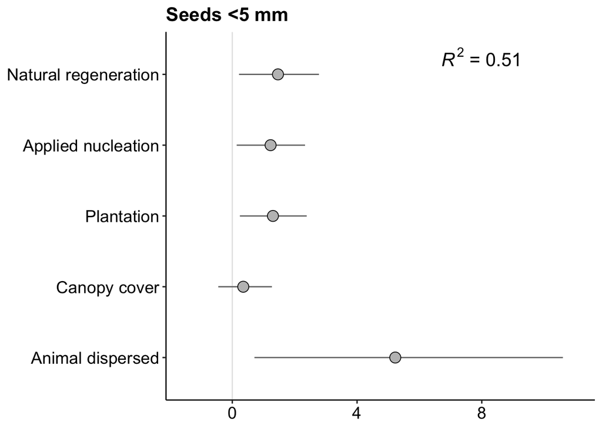

```r
#-------------------------------
# small seeds (<5 mm)
# posterior
posterior_SmallSeed <- as.array(finalModSTS_forFig2A)
dimnames(posterior_SmallSeed)$parameters[2] <- "Natural regeneration"
dimnames(posterior_SmallSeed)$parameters[3] <- "Applied nucleation"
dimnames(posterior_SmallSeed)$parameters[4] <- "Plantation"
dimnames(posterior_SmallSeed)$parameters[5] <- "Canopy cover"
dimnames(posterior_SmallSeed)$parameters[6] <- "Animal dispersed"

color_scheme_set("darkgray")
# FIGURED!
STSFig2_a <- mcmc_intervals(posterior_SmallSeed, prob = 0, prob_outer = 0.95,
                           pars = c("Natural regeneration", "Applied nucleation",
                                    "Plantation", "Canopy cover",
                                    "Animal dispersed"))+
                           labs(title="Seeds <5 mm")+
                           theme_pubr()+
                           theme(axis.text.x = element_text(size = 14),
                                 axis.text.y = element_text(size = 14),
                                 plot.title = element_text(size=16, face="bold"))+
                           xlim(-1.5, 11)+
                           annotate("text", x = 8, y = 5.25, label = "paste(italic(R) ^ 2, \" = 0.51\")", parse = TRUE, size = 5.5)
STSFig2_a
```

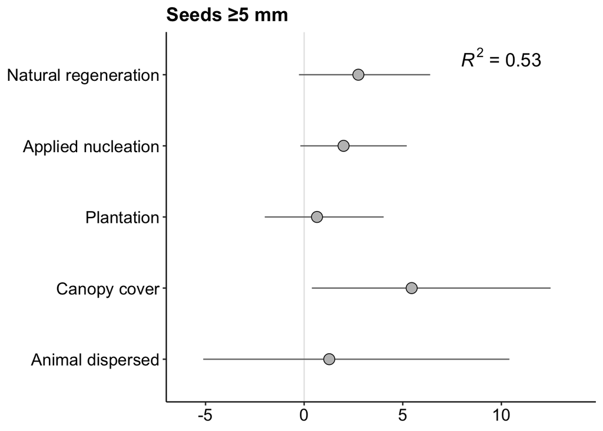

```r
#-------------------------------
# large seeds (>=5 mm)
# posterior
posterior_LargeSeed <- as.array(finalModSTS_forFig2B)
dimnames(posterior_LargeSeed)$parameters[2] <- "Natural regeneration"
dimnames(posterior_LargeSeed)$parameters[3] <- "Applied nucleation"
dimnames(posterior_LargeSeed)$parameters[4] <- "Plantation"
dimnames(posterior_LargeSeed)$parameters[5] <- "Canopy cover"
dimnames(posterior_LargeSeed)$parameters[6] <- "Animal dispersed"

color_scheme_set("darkgray")

STSFig2_b <- mcmc_intervals(posterior_LargeSeed, prob = 0, prob_outer = 0.95,
                            pars = c("Natural regeneration", "Applied nucleation",
                                     "Plantation", "Canopy cover",
                                     "Animal dispersed"))+
                           labs(title="Seeds \u22655 mm")+
                           theme_pubr()+
                           theme(axis.text.x = element_text(size = 14),
                                 axis.text.y = element_text(size = 14),
                                 plot.title = element_text(size=16, face="bold"))+
                           xlim(-6, 13.8)+
                           annotate("text", x = 10, y = 5.25, label = "paste(italic(R) ^ 2, \" = 0.53\")", parse = TRUE, size = 5.5)
STSFig2_b
```

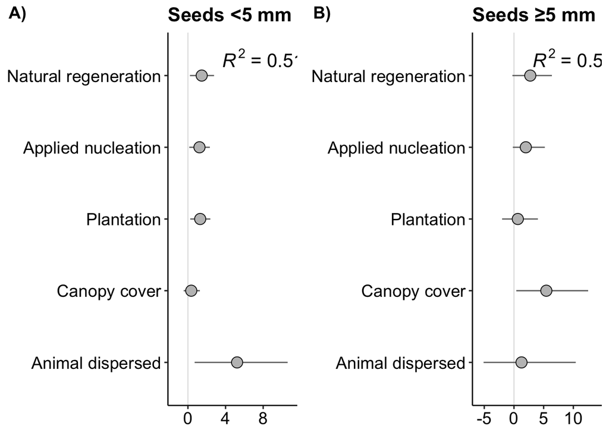

```r
# Make Figure 1
Figure2 <- ggarrange(STSFig2_a, STSFig2_b, labels = c("A)", "B)"), ncol = 2, nrow = 1)
Figure2
```

```r
ggsave("Figure2.pdf", width = 14, height = 6, units = "in", dpi = 600, device = cairo_pdf)
```

## Additional summaries for results section

### Focal species list & total seeds and seedling recruit summaries

Compute observed seed and seedling summaries and make Table 1 (focal species) and Table S2 (seed and seedling summaries by species)

```r
# focal species seed and seedling summaries
seedSeedlingSummary_byTreat <- seedsAndSeedlings_ByPlot_all %>%
                               group_by(Species, Treatment) %>%
                               summarize(plotOccurrence_Seeds= sum(present_seeds, na.rm = TRUE), # sum of seeds arriving in all treatments
                                         totalSeeds = sum(seedsSum, na.rm = TRUE),
                                         totalSeedlings = sum(count_seedling, na.rm = TRUE)) %>% # sum of seedlings arriving in all treatments
                               filter(plotOccurrence_Seeds >=2 & Species != c("ACN_ARB") & Species != c("RUA_GLA")) %>% # filter to select focal species used in randomizations/modeling
                               dplyr::select(-plotOccurrence_Seeds)

# Table S2 seed and seedling totals by species
TableS2 <- seedSeedlingSummary_byTreat %>%
           gather(variable, value, -(Treatment:Species)) %>%
           unite(temp, Treatment, variable) %>%
           spread(temp, value)


# Table focal species info.
Table1_join <- inner_join(TableS2, islasTraits, by = "Species")
Table1 <- Table1_join %>%
           dplyr::select(Species, Family, Genus, SpecificEpithet, Growthform, Dispersalmode, SuccessionalStage, SeedSize)  %>%
           mutate(seedSizeCat="NA") %>%
           mutate(seedSizeCat = ifelse(SeedSize == 1, "<5 mm", seedSizeCat)) %>%
           mutate(seedSizeCat = ifelse(SeedSize == 2, "\u22655 mm", seedSizeCat)) %>%
           dplyr::select(-SeedSize)

names(Table1)[8] <- "SeedSize"

#------
# compute summaries
#total observed seeds = 320,701
totalSeeds <- sum(seedSeedlingSummary_byTreat$totalSeeds)
totalSeeds
```

```
## [1] 320701
```

```r
#total observed seedlings = 598
totalSeedlings <- sum(seedSeedlingSummary_byTreat$totalSeedlings)
totalSeedlings
```

```
## [1] 598
```

```r
# total nummber of species = 43
length(unique(seedSeedlingSummary_byTreat$Species))
```

```
## [1] 43
```

```r
## total observed seeds - 99.9%
seedsAndSeedlings_ByPlot_all$seedsSum <- as.numeric(seedsAndSeedlings_ByPlot_all$seedsSum)
(totalSeeds/with(seedsAndSeedlings_ByPlot_all, sum(seedsSum, na.rm = TRUE)))*100
```

```
## [1] 99.85832
```

```r
## total observed seedlings - 70.0%
(totalSeedlings/with(seedsAndSeedlings_ByPlot_all, sum(count_seedling), na.rm = TRUE))*100
```

```
## [1] 70.02342
```

```r
# HEL_APP/LIP_MYR totals
seedSeedlingSummary_bySpp <- seedSeedlingSummary_byTreat %>%
                             group_by(Species) %>%
                             summarize(totalSeedsBySpp = sum(totalSeeds))

totalHELAPP <- seedSeedlingSummary_bySpp[seedSeedlingSummary_bySpp$Species == "HEL_APP",2]
totalLIPMYR <- seedSeedlingSummary_bySpp[seedSeedlingSummary_bySpp$Species == "LIP_MYR",2]

# HEL_APP/LIP_MYR percentage of total
(totalHELAPP+totalLIPMYR)/totalSeeds*100
```

```
##   totalSeedsBySpp
## 1        40.56956
```

### Summarize percent canopy cover data for Question 1 results

```r
# calculate percent cover by treatment for summaries in manuscript
# make standard error fxn
stdError <- function(x) sd(x)/sqrt(length(x))
# percent cover and SE by treatment calculation
vegStructureSummary_forMs <- vegStructureSummary %>%
                             group_by(Treatment) %>%
                             summarize(coverAll_mean = mean(meanCover),
                                       coverAll_SE = stdError(meanCover))
vegStructureSummary_forMs
```

```
## # A tibble: 4 x 3
##   Treatment coverAll_mean coverAll_SE
##   <fct>             <dbl>       <dbl>
## 1 C                  58.4       7.06
## 2 I                  89.3       1.19
## 3 P                  93.7       0.392
## 4 R                  92.6       0.383
```

### Final figures/table objects from analyses above:

Figures –  
Figure 2: Figure2  
Figure 3: Figure3  
Figure S1: FigureS1  
Figure S2: FigureS2

Tables –  
Table 1: Table1  
Table 2: Table2  
Table S2: TableS2  
Table S3: TableS3

#### References

Muscarella, R., Uriarte, M., Forero-Montaña, J., Comita, L. S., Swenson, N. G., Thompson, J., … Zimmerman, J. K. (2013). Life-history trade-offs during the seed-to-seedling transition in a subtropical wet forest community. *Journal of Ecology* 101(1): 171–182. doi:10.1111/1365-2745.12027

Norden, N., Chave, J., Belbenoit, P., Caubère, A., Chatelet, P., Forget, P.-M., … Thebaud, C. 2009. Interspecific variation in seedling responses to seed limitation and habitat conditions for 14 Neotropical woody species. *Journal of Ecology*, 97(1): 186–197. doi:10.1111/j.1365-2745.2008.01444.x